# US Bankruptcy Filings

## Trends, Drivers & Geographic Concentration

### A Data-Driven Analysis for Risk Professionals

**Data through:** Q1 2026 · **Source:** US Courts + FRED · **Coverage:** 38 quarters, 2016 Q3 – 2026 Q1

## Executive Summary — Q1 2026

[output not shown]

> Filings remain **~25% below pre-pandemic levels** (~800,000 in 2016–2019). This is normalization — not a crisis wave. But momentum is re-accelerating.

## The Recovery Trajectory

12-Month Rolling National Filings · 2016–2026

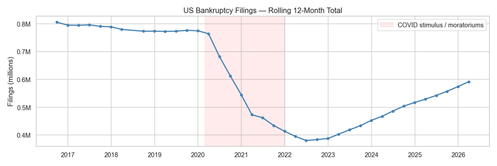

```python
show('01_national_total.png')
```

## Three Phases of the Cycle

| Phase | Period | Filings | Driver |
| --- | --- | --- | --- |
| Pre-pandemic baseline | 2016–2019 | ~800,000 | Normal credit cycle |
| Stimulus suppression | 2020–2022 | 380,634 (trough) | PPP, stimulus checks, moratoriums |
| **Normalization** | **2023–present** | **591,850** | **Debt service pressure resuming** |

## Sustained Double-Digit Growth

Year-over-Year Change in 12-Month Rolling Filings

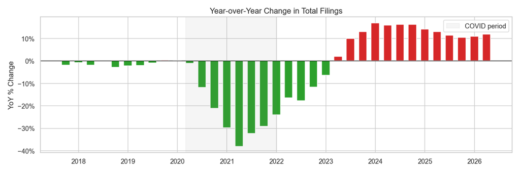

```python
show('01_yoy_growth.png')
```

## Quarterly Momentum (3-Month Snapshots)

Same-Quarter Prior-Year (SQPY) growth removes seasonal distortion

| Quarter | 3-Mo Filings | QoQ | **SQPY** | Ch.11 | **Ch.11 SQPY** |
| --- | --- | --- | --- | --- | --- |
| Q4 2024 | 127,921 | −4.6% | +11.5% | 2,085 | −5.7% |
| Q1 2025 | 134,063 | +4.8% | +9.6% | 2,039 | −2.9% |
| Q2 2025 | 146,162 | +9.0% | +10.1% | 2,138 | −17.0% |
| Q3 2025 | 148,821 | +1.8% | +11.0% | 2,659 | +26.3% |
| Q4 2025 | 144,620 | −2.8% | +13.1% | 2,355 | +12.9% |
| **Q1 2026** | **152,262** | **+5.3%** | **+13.6%** | **2,784** | **+36.5%** |

After moderating through mid-2025, SQPY is **re-accelerating to +13.6%**. Ch.11 SQPY at **+36.5%** is the strongest reading in 12 months.

## Chapter Composition — Q1 2026

591,850 annual filings

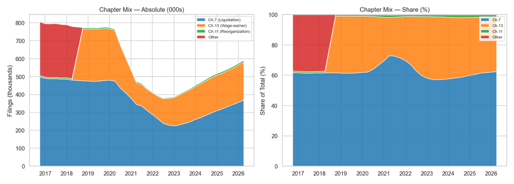

```python
show('01_chapter_mix.png')
```

## Chapter Breakdown

| Chapter | Filings | Share | Nature |
| --- | --- | --- | --- |
| **Ch. 7** | 369,702 | 62.5% | Liquidation — immediate discharge |
| **Ch. 13** | 211,700 | 35.8% | Individual reorganization (3–5 yr plan) |
| **Ch. 11** | 9,941 | 1.7% | Business restructuring |
| Other | ~507 | 0.1% | Agricultural, cross-border |

The **Ch.7 / Ch.13 ratio** varies sharply by geography — a key portfolio risk signal (see Geographic section).

## Chapter 11: The Corporate Stress Indicator

Annual Ch.11 Filings — All-Time High in Dataset

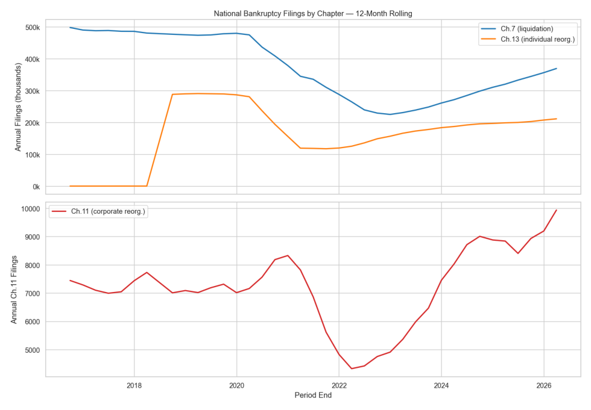

```python
show('05_ch11_national_trend.png')
```

## Ch.11: Business vs. Non-Business

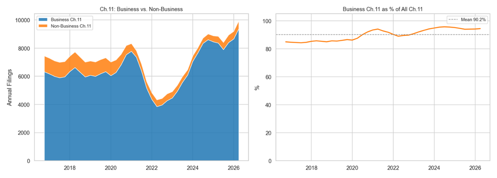

```python
show('05_ch11_biz_split.png')
```

## The SBRA Structural Shift

|  | Filings | Share |
| --- | --- | --- |
| Business Ch.11 | **9,385** | **94.4%** |
| Non-business Ch.11 | 556 | 5.6% |

The **Small Business Reorganization Act (SBRA, Feb 2020)** created *Subchapter V* — a streamlined, lower-cost reorganization track for businesses with debts under $7.5M.

Subchapter V dramatically reduced the cost and complexity barrier to Ch.11 for small businesses. **The pre-2020 Ch.11 baseline is obsolete as a benchmark.**

## What Actually Predicts Bankruptcy Filings

Correlation with 13 FRED Macroeconomic Series

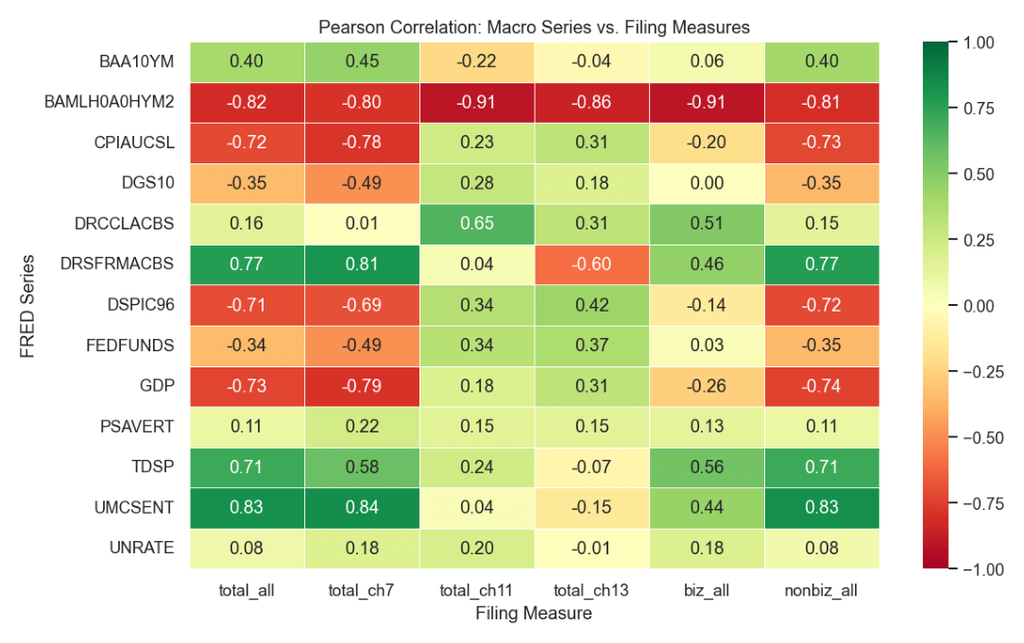

```python
show('02_correlation_heatmap.png', figsize=(10, 6))
```

## The Predictors That Matter

[output not shown]

> Bankruptcy is a **debt-stock event**, not a job-loss event. Accumulated obligations become unserviceable *independent of employment status*. Models that lead with unemployment will systematically mis-time the cycle.

## The 2020–2022 Stimulus Distortion

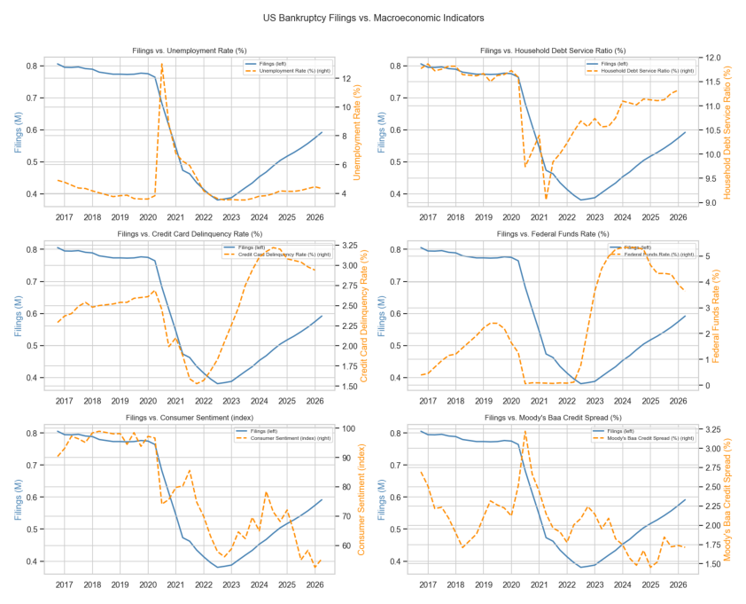

```python
show('02_macro_overlay.png')
```

> ⚠️ **Model calibration warning:** PPP loans, stimulus checks, eviction moratoriums, and student loan forbearance collectively suppressed filings to 50-year lows. **Exclude 2020–2022 from long-run parameter estimation.**

## Geographic Distribution

Top States by Annual Filing Volume · Q1 2026

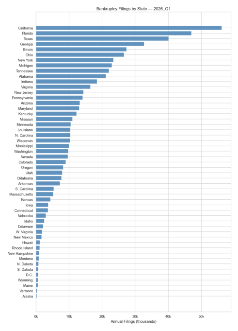

```python
show('06_state_totals.png')
```

Top 10 states = **~56% of national filings**. Florida **+22.3%** and Texas **+22.2%** are the fastest-growing large states.

## The North–South Chapter Split

Chapter Mix by State

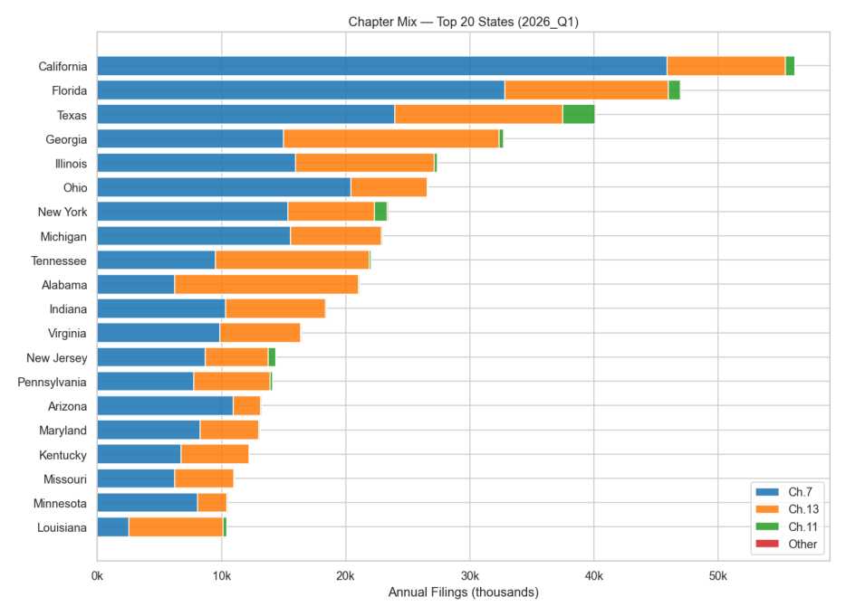

```python
show('06_state_chapter_mix.png')
```

## Southern States: A Different Bankruptcy Culture

| Region | Ch.13 Rate |  |
| --- | --- | --- |
| Alabama, Tennessee, Georgia | 50–70% | Ch.13 dominant |
| West Coast, New England | 15–30% | Ch.7 dominant |
| National average | ~36% |  |

Southern bankruptcy bar culture historically favors Ch.13 reorganization over Ch.7 liquidation — reflecting trustee practices, judicial culture, and home-ownership defense (Ch.13 allows curing mortgage arrears; Ch.7 does not).

> **Portfolio implication:** Southern borrowers who file extend workout timelines to 3–5 years vs. 3–6 months in Ch.7 states.

## YoY Growth: Nationwide Breadth

Year-over-Year Filing Change by State · Q1 2026 vs Q1 2025

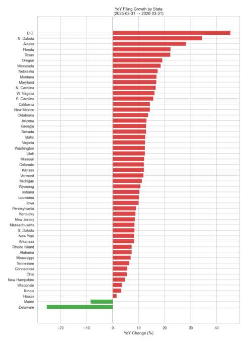

```python
show('06_state_yoy.png')
```

**49 of 51 jurisdictions** posted YoY increases. Breadth of this magnitude signals **systemic financial pressure**, not regional shocks.

## Business Ch.11 Venue Concentration

Top Federal Districts · Forum-Shopping Map

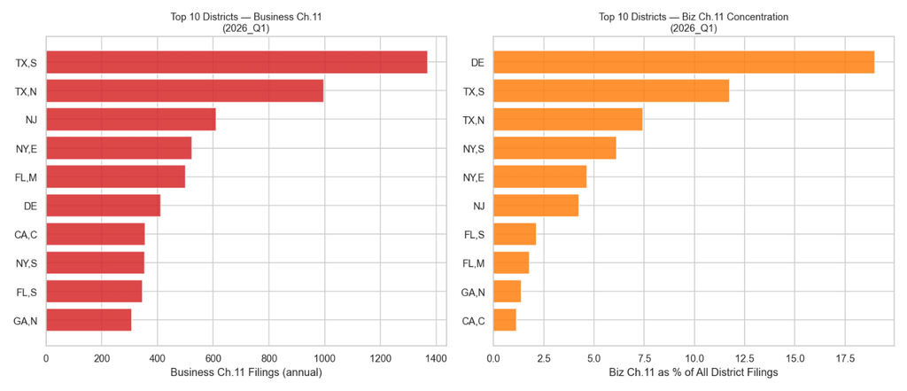

```python
show('05_ch11_districts.png')
```

## The Key Ch.11 Venues

| Jurisdiction | Biz Ch.11 | % of District | Note |
| --- | --- | --- | --- |
| Texas Southern (Houston) | 1,369 | 11.8% | Dominant large-case venue |
| Texas Northern (Dallas) | 996 | 7.4% |  |
| **Delaware** | **412** | **19.0%** | Highest concentration nationally |
| New Jersey | 610 | 4.2% | Tri-state alternative |
| NY Eastern (Brooklyn) | 524 | 4.7% | Growing venue |
| NY Southern (Manhattan) | 353 | 6.1% | Traditional large-case venue |

## Risk Implications for Credit Professionals

**1. Monitor household debt service, not unemployment** TDSP and mortgage delinquency rates lead the cycle. Unemployment is a lagging distractor.

**2. Business reorganization is structurally elevated** Subchapter V permanently lowered the Ch.11 barrier. Pre-2020 baselines are obsolete.

**3. Geographic exposure matters — especially in the South** High-Ch.13 states mean 3–5 year workout timelines for mortgage and consumer portfolios.

## Risk Implications (cont.)

**4. The recovery is broad and re-accelerating** 49/51 states growing. SQPY ticking back up to +13.6%. Normalization to pre-pandemic levels is not complete.

**5. Exclude 2020–2022 from model calibration** Stimulus effects created a once-in-a-generation false floor. Models trained on that period will systematically underpredict stress in the current environment.

## Data & Methodology

**Bankruptcy data** — US Courts Quarterly Bankruptcy Filing Statistics

**Macroeconomic data** — FRED, Federal Reserve Bank of St. Louis

**Processing**

- Storage: DuckDB · All percentages use rolling 12-month denominators
- SQPY growth used to remove bankruptcy filing seasonality

**Live dashboard:** bankruptcy-dashboard.vercel.app — updates automatically each quarter